# CAH - TD

Dans ce TD, nous aborderons la réalisation de la CAH sous R. Vous devez exécuter l’ensemble des commandes réalisées ici (et les comprendre), afin de pouvoir les reproduire.

Nous allons utiliser d’autres packages (inclus dans le chargement du package `tidyverse`) pour réaliser les graphiques et autres tableaux, ainsi que la librairie `FactoMineR` pour la réalisation des analyses factorielles.

```r
library(tidyverse)
library(FactoMineR)
```

## Réalisation d’une CAH

### Calcul de la distance

Avant de calculer l’arbre hiérarchique, il nous faut calculer les distances entre les individus. Pour cela, nous utilisons la fonction `dist()`, qui renvoie la matrice de distance. Par défaut, la distance utilisée est la distance euclidienne. Le paramètre `method` permet de choisir celle-ci (`"manhattan"` pour la distance $L_1$ par exemple).

```r
df = head(faithful)
d = dist(df)
d
```

```
          1         2         3         4         5
2 25.064716
3  5.007124 20.058666
4 17.050938  8.014567 12.045850
5  6.072107 31.120239 11.065261 23.109792
6 24.010708  1.474072 19.005328  7.025667 30.045341
```

### Calcul de l’arbre

La fonction `hclust()` permet de calculer le dendrogramme à partir de la matrice de distance. Par défaut, la méthode utilisée est le lien complet. C’est le paramètre `method` qui permet de définir le critère d’agrégation que l’on veut (par exemple `single` pour lien simple ou `ward.D2` pour le critère de Ward).

```r
a = hclust(d)
a
```

```
Call:
hclust(d = d)

Cluster method   : complete
Distance         : euclidean
Number of objects: 6
```

### Représentation de l’arbre

Pour visualiser l’abre, on utilise la fonction `plot()`.

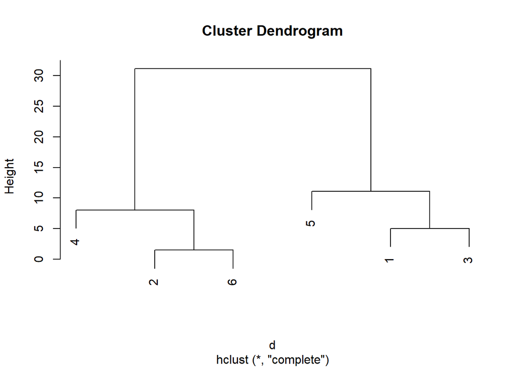

```r
plot(a)
```

On peut choisir de faire démarrer les feuilles sur la même ligne avec le paramètre `hang`, comme ci-dessous.

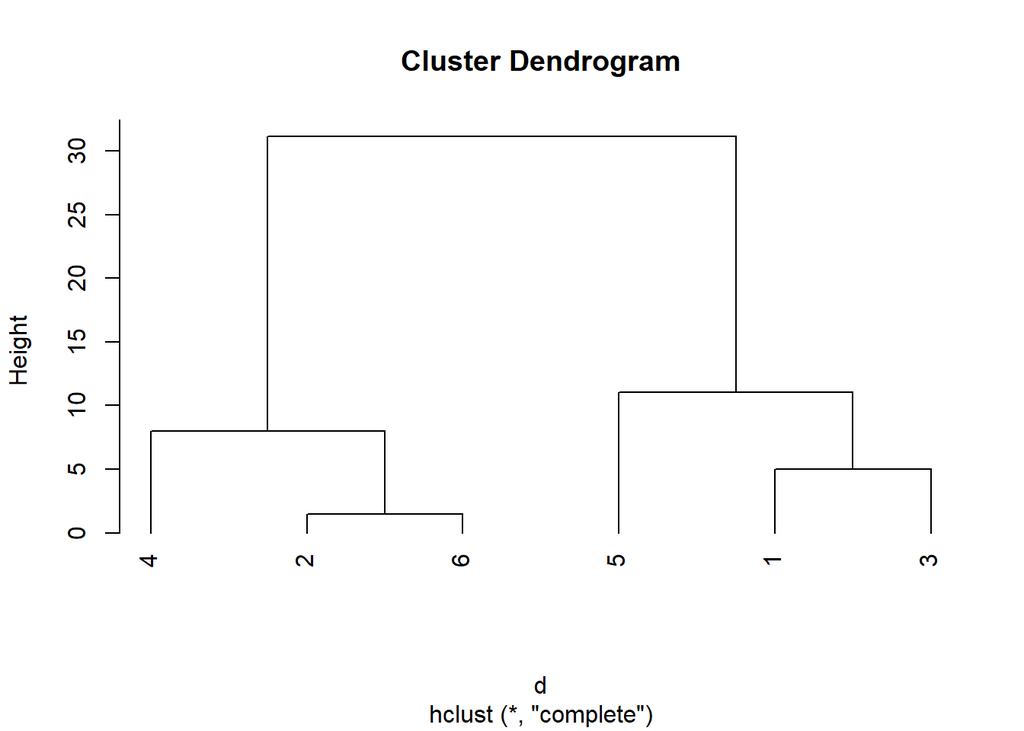

```r
plot(a, hang = -1)
```

### Découpage de l’arbre

Si l’on veut la partition obtenue en découpant l’arbre en $K$ classes, on doit utiliser la fonction `cutree()`, en indiquant le nombre de classes voulu avec le paramètre `k`.

```r
z = cutree(a, k = 2)
z
```

```
1 2 3 4 5 6
1 2 1 2 1 2
```

On peut aussi définir une valeur de découpe avec le paramètre `h`.

```r
z = cutree(a, h = 25)
z
```

```
1 2 3 4 5 6
1 2 1 2 1 2
```

### Description des classes

Une partition peut être vue comme une nouvelle variable qualitative de notre jeu de données. Nous pouvons donc calculer des caractéristiques statistiques des autres variables (qui ont servi à faire la CAH ou non) pour décrire les variables.

Dans notre cas, nous allons calculer les moyennes des deux variables pour chaque classe.

```r
df %>%
  mutate(classe = z) %>%
  group_by(classe) %>%
  summarise(
    nb_individus = n(),
    waiting = mean(waiting),
    eruptions = mean(eruptions)
  )
```

```
# A tibble: 2 x 4
  classe nb_individus  waiting eruptions
   <int>        <int>    <dbl>     <dbl>
1      1            3 79.33333     3.822
2      2            3 57.00000     2.322
```

### Représentation des classes

Une fois le nombre de classes (ou la hauteur) choisi, on peut afficher les classes sur le dendrogramme à l’aide de la fonction `rect.hclust()`.

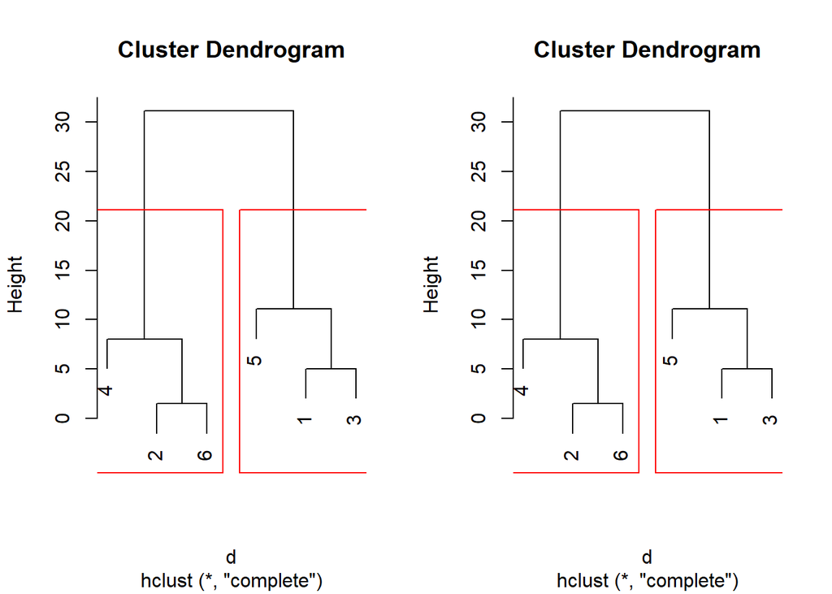

```r
par(mfrow = c(1, 2))
plot(a)
rect.hclust(a, k = 2)
plot(a)
rect.hclust(a, h = 25)
```

Il est aussi d’usage de représenter les individus avec une couleur par classe. Ici, puisque nous avons uniquement 2 variables, nous allons nous contenter de faire le nuage de points avec donc une couleur en fonction de la classe.

Avec la fonction `plot()` de base :

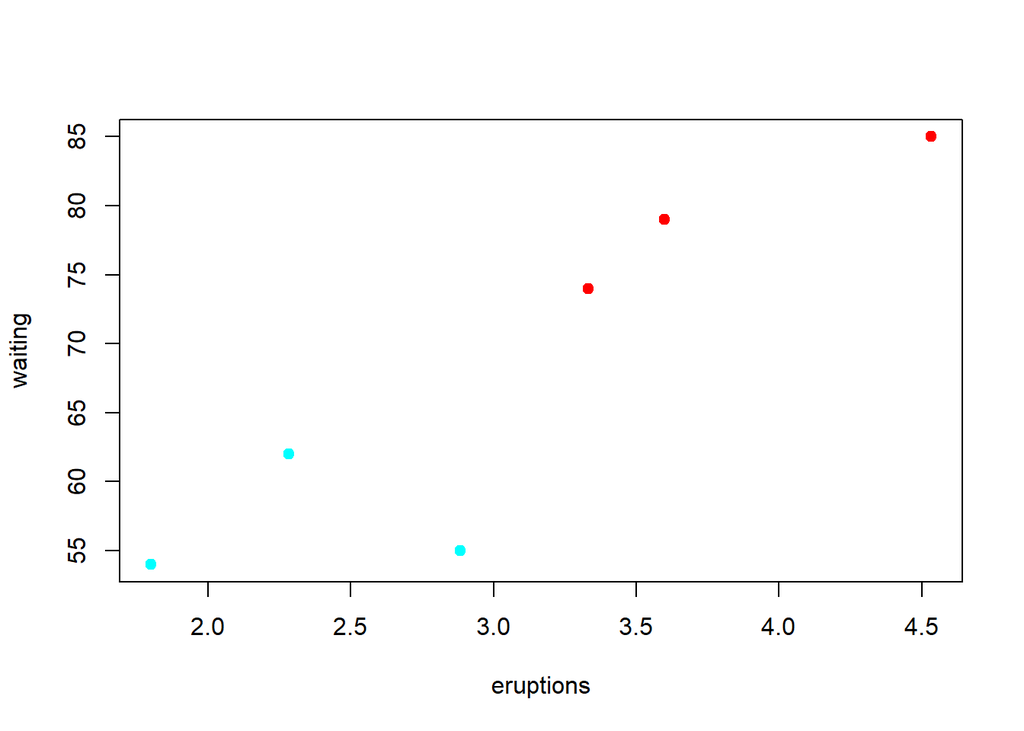

```r
plot(df, col = rainbow(2)[z], pch = 19)
```

Avec `ggplot()` :

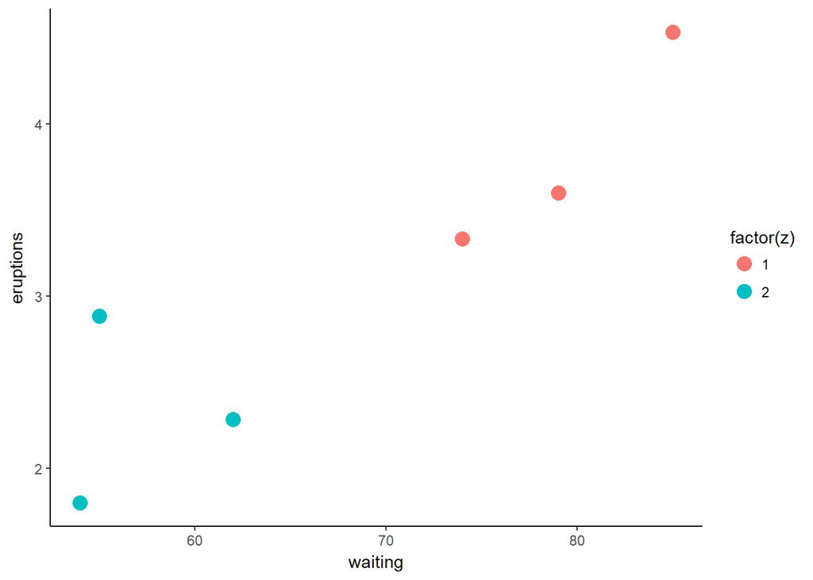

```r
df %>%
  mutate(classe = z) %>%
  ggplot(aes(waiting, eruptions, col = factor(z))) +
  geom_point(size = 4) +
  theme_classic()
```

Toutefois, si nous avions eu plus de variables, deux possibilités s’offrent à nous :

- représenter l’ensemble des nuages de points possibles (possible si nombre de variables peu importants) ,
- représenter la partition sur les premiers axes d’une ACP.

### Application sur les données complètes

Nous allons appliquer la CAH sur les données `faithful` complètes. Puisque les deux variables présentes n’ont pas la même distribution, nous allons normaliser les variables avant le calcul de la distance. Sans cette étape, la variable `waiting` prendrait toute l’importance.

Nous allons tester deux distances (euclidienne - par défaut, et manhattan), ainsi que trois méthodes (lien complet - par défaut, lien simple et critère de Ward).

Le code ci-dessus permet donc de créer les 6 arbres voulus.

```r
faithful_scale = scale(faithful)
d_euc = dist(faithful_scale)
a_euc_complet = hclust(d_euc)
a_euc_simple = hclust(d_euc, method = "single")
a_euc_ward = hclust(d_euc, method = "ward.D2")
d_man = dist(faithful_scale, method = "manhattan")
a_man_complet = hclust(d_man)
a_man_simple = hclust(d_man, method = "single")
a_man_ward = hclust(d_man, method = "ward.D2")
```

Et ce code permet de les visualiser.

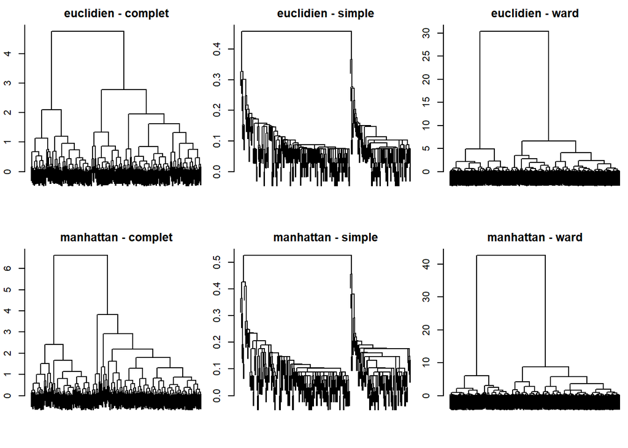

```r
par(mfrow = c(2, 3), mar = c(2, 2, 2, 0) + .1)
plot(a_euc_complet, labels = FALSE, main = "euclidien - complet")
plot(a_euc_simple, labels = FALSE, main = "euclidien - simple")
plot(a_euc_ward, labels = FALSE, main = "euclidien - ward")
plot(a_man_complet, labels = FALSE, main = "manhattan - complet")
plot(a_man_simple, labels = FALSE, main = "manhattan - simple")
plot(a_man_ward, labels = FALSE, main = "manhattan - ward")
```

Pour récupérer les 6 partitions, nous utilisons donc la fonction `cutree()` comme ci-dessous.

```r
z_euc_complet = cutree(a_euc_complet, k = 2)
z_euc_simple = cutree(a_euc_simple, k = 2)
z_euc_ward = cutree(a_euc_ward, k = 2)
z_man_complet = cutree(a_man_complet, k = 2)
z_man_simple = cutree(a_man_simple, k = 2)
z_man_ward = cutree(a_man_ward, k = 2)
```

Bien que les arbres soient tous différents, les 6 partitions semblent toutes identiques ici. Ce phénomène est assez rare toutefois.

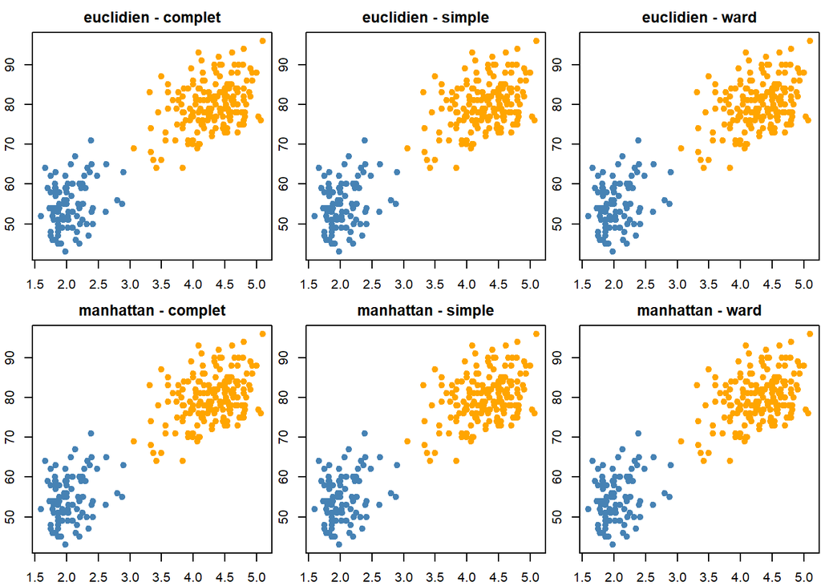

```r
coul = c("orange", "steelblue")
par(mfrow = c(2, 3), mar = c(2, 2, 2, 0) + .1)
plot(faithful, col = coul[z_euc_complet],
     pch = 19, main = "euclidien - complet")
plot(faithful, col = coul[z_euc_simple],
     pch = 19, main = "euclidien - simple")
plot(faithful, col = coul[z_euc_ward],
     pch = 19, main = "euclidien - ward")
plot(faithful, col = coul[z_man_complet],
     pch = 19, main = "manhattan - complet")
plot(faithful, col = coul[z_man_simple],
     pch = 19, main = "manhattan - simple")
plot(faithful, col = coul[z_man_ward],
     pch = 19, main = "manhattan - ward")
```

## Application sur les résultats d’une méthode factorielle

Comme déjà évoqué dans les précédents cours et TD, il est possible de réaliser une classification sur les axes factorielles obtenus avec soit une ACP, soit une ACM.

Dans le cadre d’une CAH sur une ACP, l’idée est de pouvoir limiter le *bruit* dans les données, en ne sélectionnant que les axes les plus informatifs.

Dans le cadre d’une CAH sur une ACM, l’idée est ici de pouvoir réaliser effectivement une classification, car nous n’avons pas à notre disposition (dans R de base) d’outils pour calculer des distances entre individus décrits par des variables qualitatives.

On peut aussi réaliser une CAH sur les résultats d’une AFC faite sur des données quantitatives positives.

### Sur une ACP

En appliquant une ACP sur les données `faithful`, on s’aperçoit que le premier axe explique à lui seul 95% de l’information. Nous allons donc réaliser la CAH uniquement sur cet axe. Dans ce cas, nous utilisons très généralement le critère de Ward sur les distances euclidiennes.

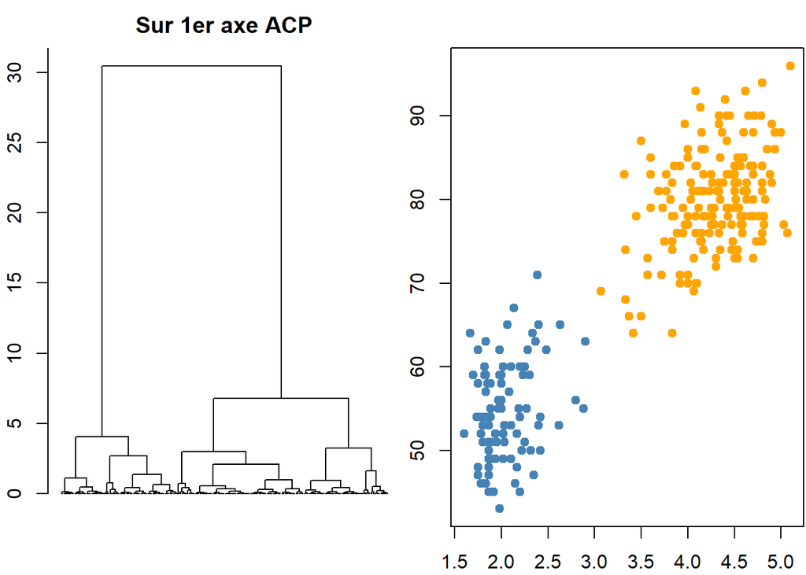

```r
par(mar = c(2, 2, 2, 0) + .1, mfrow = c(1, 2))
acp = PCA(faithful, graph = F)
a_acp = hclust(dist(acp$ind$coord[,1]), "ward.D2")
z_acp = cutree(a_acp, 2)
plot(a_acp, labels = FALSE, hang = -1, main = "Sur 1er axe ACP")
plot(faithful, col = coul[z_acp], pch = 19)
```

### Sur une ACM

Ici, pour avoir un maximum d’information, nous choissisons de garder 6 axes, ce qui représente plus de 80% de l’information (81.7% exactement).

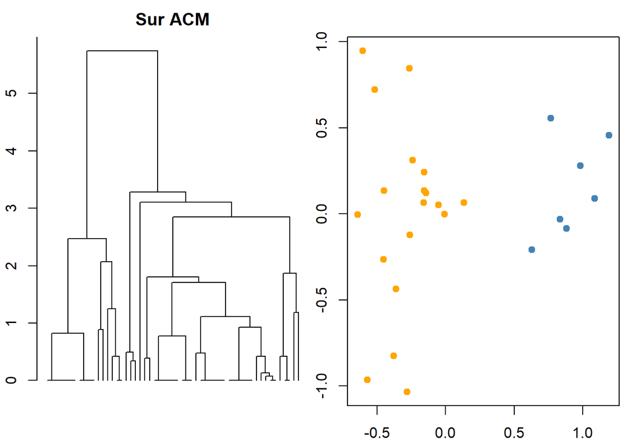

```r
par(mar = c(2, 2, 2, 0) + .1, mfrow = c(1, 2))
data(poison)
acm = MCA(poison[,5:15], graph = FALSE, ncp = 6)
a_acm = hclust(dist(acm$ind$coord[,1:6]), "ward.D2")
z_acm = cutree(a_acm, 2)
plot(a_acm, labels = FALSE, hang = -1, main = "Sur ACM")
plot(acm$ind$coord, col = coul[z_acm], pch = 19)
```

## A faire

La [banque mondiale](http://www.banquemondiale.org) fournit un grand nombre de données, dont des indicateurs de gouvernance au niveau mondial (voir [ici](https://data.worldbank.org/data-catalog/worldwide-governance-indicators)). Le code ci-dessous importe les données du fichier `WGI_Data.csv` (que vous devez donc télécharger) pour les importer. Les informations concernant la définition des indicateurs et leur source se trouvent dans le fichier `WGI_Definition and Source.csv`.

```r
wgi.m = read_csv("WGI_Data.csv", quote = '"') %>%
  mutate_at("Value", funs(as.numeric))
wgi = wgi.m %>%
  select(`Country Name`, `Series Code`, Value) %>%
  spread(`Series Code`, Value) %>%
  rename_at(vars(ends_with("EST")), funs(sub(".EST", "", .)))
```

| Country Name | CC | GE | PV | RL | RQ | VA |
| --- | --- | --- | --- | --- | --- | --- |
| Afghanistan | -1.56 | -1.22 | -2.75 | -1.62 | -1.33 | -1.09 |
| Albania | -0.40 | 0.00 | 0.26 | -0.35 | 0.19 | 0.16 |
| Algeria | -0.69 | -0.54 | -1.14 | -0.85 | -1.17 | -0.88 |
| American Samoa | 1.23 | 0.53 | 1.19 | 1.33 | 0.14 | NA |
| Andorra | 1.23 | 1.86 | 1.40 | 1.56 | 0.87 | 1.20 |
| Angola | -1.41 | -1.04 | -0.39 | -1.08 | -1.00 | -1.17 |

Vous devez donc réaliser les étapes suivantes :

- Réaliser la CAH, avec la distance euclidienne et comme critère d’agrégation :
  - lien complet
  - lien simple
  - critère de Ward
- Visualiser les arbres hiérarchiques et choisir un nombre de classes
- Décrire les classes ainsi obtenues pour chaque critère
- Réaliser une ACP pour visualiser les partitions obtenues sur le premier plan factoriel
- Comparer les partitions obtenues
- Réaliser une CAH (avec distance euclienne et critère de Ward) sur les premiers axes de l’ACP
  - déterminer le nombre de classes idéal
  - comparer la partition avec les autres